# Relatório da Escala de Crenças e Práticas

Guilherme e Jéssica

13-11-2014

# 1 Introduçao

Este relatório objetiva apresentar as análises exploratória do instrumento ``Escala de práticas na prevenção do uso de álcool e outras drogas’’, que está em fase de desenvolvimento pelo [Centro de Referência em Pesquisa, Intervenção e Avaliação em Álcool e Outras Drogas](http://www.ufjf.br/crepeia/).

O instrumento está sendo validado para população de educadores. O objetivo da pesquisa é oferecer uma medida confiável para avaliação das práticas profissionais de educadores de um curso à distância oferecido pela Secretaria Nacional de Políticas sobre Drogas para aproximadamente 10.000 educadores dos estados de Minas Gerais e Rio de Janeiro.

Durante todo o processo de desenvolvimento, foram utilizadas ferramentas de código-aberto, para facilitar o re-uso das técnicas e procedimentos desenvolvidos. Todo conteúdo do instrumento e de suas etapas estará disponível para o público no repositório (http://github.com/crepeia/ead-senad).

Neste relatório são apresentadas, análises da escala com base em uma amostra de 3064 educadores do curso. As análises foram conduzidas através da linguagem de programação R usando os pacotes *car* e *psych*.

## 1.1 Banco de Dados

O banco de dados da pesquisa, pode ser obtido no seguinte endereço: (https://github.com/henriquepgomide/ead-senad/blob/master/praticasprofissionais_df.csv).

## 1.2 Resultados

Os resultados são apresentados por tópicos: caracterização da amostra, avaliação descritiva da escala e análise fatorial exploratória.

### 1.2.1 Bibliotecas

```r
# Load R packages
library(car)       # Function Recode
library(psych)     # Function Describe
library(mirt)      # Function bfactor
```

```r
library(ggplot2)   # Fancy Charts
library(xtable)    # HTML tables


## Import dataframe
praticasPro  <- read.csv("praticasprofissionais_df.csv")

## Sum scales to remove NA's
praticasPro$scaleSum  <- rowSums(praticasPro[,32:68])
```

### 1.2.2 Participantes que recusaram

#### 1.2.2.1 Termo consentimento

```r
table(praticasPro$termo=="Sim", useNA = "always")
```

```
##
## FALSE  TRUE  <NA>
##   122  3247   267
```

```r
# Porcentagem de recusas
(122+267)/3636*100
```

```
## [1] 10.69857
```

```r
## Subset consented participation
praticasPro  <- subset(praticasPro, subset=praticasPro$termo=="Sim")
```

A porcentagem de recusas em participar ou não preenchimento da questão 10.69%.

#### 1.2.2.2 Não preencheram toda a escala

```r
# Table with complete cases
table(!is.na(praticasPro$scaleSum), useNA = "always")
```

```
##
## FALSE  TRUE  <NA>
##   183  3064     0
```

```r
183/(183+3064)*100
```

```
## [1] 5.635972
```

```r
## Subset completed observations
praticasPro  <- subset(praticasPro, subset=!is.na(praticasPro$scaleSum))
```

A porcentagem de pessoas que não preencheram toda a escala foi de 5.64%

### 1.2.3 Sócio-demográficas

#### 1.2.3.1 Idade

```r
## Age
### Clean data
praticasPro$idade  <- as.numeric(as.character(praticasPro$idade))          ### Convert into numeric
praticasPro$idade[praticasPro$idade < 18 | praticasPro$idade > 68 ]  <- NA ### Remove cases
### Descriptives
summary(praticasPro$idade) # all
```

```
##    Min. 1st Qu.  Median    Mean 3rd Qu.    Max.    NA's
##   19.00   34.00   41.00   40.75   47.00   68.00     332
```

```r
by(praticasPro$idade, praticasPro$sexo, describe) #by sex
```

```
## praticasPro$sexo: Feminino
##   vars    n  mean   sd median trimmed   mad min max range skew kurtosis
## 1    1 2335 40.86 8.76     41   40.77 10.38  19  68    49 0.08    -0.64
##     se
## 1 0.18
## --------------------------------------------------------
## praticasPro$sexo: Masculino
##   vars   n  mean   sd median trimmed   mad min max range skew kurtosis  se
## 1    1 396 40.12 9.95     40   39.64 10.38  21  67    46 0.38    -0.59 0.5
```

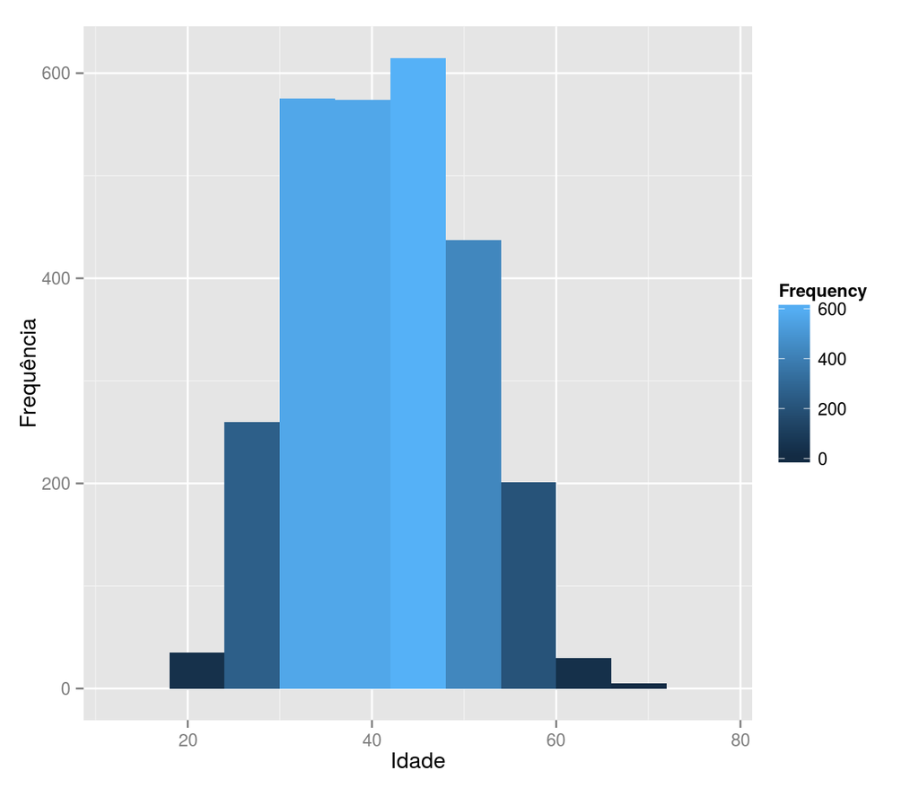

```r
ggplot(praticasPro, aes(x=idade)) + geom_histogram(aes(fill = ..count..), binwidth = 6) + xlab("Idade") + ylab("Frequência") + scale_fill_continuous(name="Frequency")
```

#### 1.2.3.2 Sexo

```r
cbind(round(prop.table(sort(table(praticasPro$sexo), decreasing = TRUE)),2))
```

```
##           [,1]
## Feminino  0.86
## Masculino 0.14
```

#### 1.2.3.3 Escolaridade

```r
cbind(round(prop.table(sort(table(praticasPro$escolaridade), decreasing = TRUE)),2))
```

```
##                               [,1]
## Pós-graduação                 0.65
## Ensino Superior Completo      0.29
## Ensino Superior Incompleto    0.05
## Ensino Médio Completo         0.01
## Ensino Fundamental Incompleto 0.00
## Ensino Médio Incompleto       0.00
## Ensino Fundamental Completo   0.00
```

#### 1.2.3.4 Estado Civil

```r
cbind(round(prop.table(sort(table(praticasPro$estadocivil), decreasing = TRUE)),2))
```

```
##                [,1]
## Casado (a)     0.58
## Solteiro (a)   0.22
## Divorciado (a) 0.09
## União Estável  0.07
## Outros         0.02
## Viúvo (a)      0.02
```

#### 1.2.3.5 Tempo de serviço

```r
timeWorking  <- as.numeric(as.character(praticasPro$tempodeservico))
timeWorking[timeWorking > 59]  <- NA
summary(timeWorking)
```

```
##    Min. 1st Qu.  Median    Mean 3rd Qu.    Max.    NA's
##    0.00    5.00   12.00   13.04   20.00   48.00     760
```

#### 1.2.3.6 Religião

```r
cbind(round(prop.table(sort(table(praticasPro$religiao), decreasing = TRUE)),2))
```

```
##              [,1]
## Católica     0.66
## Evangélica   0.19
## Espírita     0.08
## Sem religião 0.04
## Outras       0.02
## Umbanda      0.00
## Budismo      0.00
## Candomblé    0.00
```

#### 1.2.3.7 Contato com o tema

```r
cbind(round(prop.table(sort(table(praticasPro$contatoanterior), decreasing = TRUE)),2))
```

```
##     [,1]
## Sim 0.63
## Não 0.37
```

#### 1.2.3.8 Lida com

```r
cbind(round(prop.table(sort(table(praticasPro$lidadiretamente), decreasing = TRUE)),2))
```

```
##     [,1]
## Sim 0.64
## Não 0.36
```

#### 1.2.3.9 Onde lida com

```r
cbind(round(prop.table(sort(table(praticasPro$lida.onde), decreasing = TRUE)),2))
```

```
##                     [,1]
## Escola              0.35
## Família             0.23
## Comunidade          0.19
## Outros              0.13
## Amigos              0.05
## Serviços de atuação 0.04
## Serviços de saúde   0.02
```

### 1.2.4 Apresentação dos itens da escala

```r
questions  <- read.csv("praticasprofissionais_questions.csv", col.names = "Itens", header=TRUE)
print(as.character(questions[1:37,1]), type="html", justify = "left")
```

```
##  [1] " Os educadores já estão muito ocupados com suas atividades educacionais para realizarem estratégias de prevenção."
##  [2] "Como professor, sou capaz de mediar a construção colaborativa do conhecimento, e posso contribuir para realizar mudanças sociais."
##  [3] "Como educador, entendo que é papel da escola orientar seus alunos, almejando a construção colaborativa de sua identidade."
##  [4] " Admito ser necessário abordar temas como a promoção de saúde no contexto escolar."
##  [5] "A escola é o principal contexto para realização de ações em saúde e educação para os adolescentes."
##  [6] "Entendo que trabalhar com a prevenção do uso de álcool seja tão importante quanto a prevenção do uso de outras drogas."
##  [7] "Acredito que, ações para reduzir o consumo de álcool e outras drogas entre adolescentes ou atrasar o início de seu uso são positivas."
##  [8] "Considero o confronto e o \"sermão\" como os métodos mais eficazes de abordagem aos usuários de álcool e outras drogas."
##  [9] "Conheço o suficiente sobre as causas dos problemas relacionados à álcool e outras drogas para lidar com um aluno usuário de drogas."
## [10] " Oriento meus alunos sobre os padrões de consumo de risco relativos ao uso de álcool e outras drogas."
## [11] "Converso sobre os fatores de risco e proteção para o uso de álcool e outras drogas, porque os adolescentes não têm a capacidade de avaliação dos riscos."
## [12] "Realizo práticas de prevenção aos problemas relacionados ao uso de álcool e outras drogas na escola."
## [13] "Creio que a escola seja capaz de identificar possíveis ações de fortalecimento da rede de apoio ao usuário de álcool e outras drogas."
## [14] "Considero-me preparado para uma avaliação das redes sociais dos adolescentes usuários de álcool e outras drogas."
## [15] "Aceito e trabalho com a repressão ao uso de álcool e outras drogas."
```

[output cut: 22 more lines]

### 1.2.5 Itens

```r
# Create dataFrame with attitudes scale
fullScale  <- praticasPro[,32:68]

## Reverse code items according to Theory
for (i in c(1,8,11,15,18,24,25,28,33,34)) {
  fullScale[,i] <- recode(fullScale[,i], "1=5;2=4;4=2;5=1")
}

# Describe items
describe(fullScale, skew=FALSE)
```

```
##       vars    n mean   sd median trimmed  mad min max range   se
## pp001    1 3064 3.91 0.92      4    4.03 0.00   1   5     4 0.02
## pp002    2 3064 4.33 0.60      4    4.36 0.00   1   5     4 0.01
## pp003    3 3064 4.38 0.61      4    4.41 0.00   1   5     4 0.01
## pp004    4 3064 4.54 0.53      5    4.57 0.00   1   5     4 0.01
## pp005    5 3064 3.88 0.88      4    3.98 0.00   1   5     4 0.02
## pp006    6 3064 4.51 0.59      5    4.56 0.00   1   5     4 0.01
## pp007    7 3064 4.44 0.69      5    4.52 0.00   1   5     4 0.01
## pp008    8 3064 4.03 0.89      4    4.14 1.48   1   5     4 0.02
## pp009    9 3064 2.38 0.90      2    2.32 0.00   1   5     4 0.02
## pp010   10 3064 3.89 0.78      4    3.96 0.00   1   5     4 0.01
## pp011   11 3064 2.47 0.96      2    2.44 0.00   1   5     4 0.02
## pp012   12 3064 3.54 0.91      4    3.58 0.00   1   5     4 0.02
## pp013   13 3064 4.08 0.70      4    4.14 0.00   1   5     4 0.01
## pp014   14 3064 2.87 0.92      3    2.84 1.48   1   5     4 0.02
## pp015   15 3064 2.77 1.01      3    2.75 1.48   1   5     4 0.02
## pp016   16 3064 3.34 0.96      4    3.36 1.48   1   5     4 0.02
## pp017   17 3064 4.29 0.62      4    4.33 0.00   1   5     4 0.01
## pp018   18 3064 3.71 1.03      4    3.81 0.00   1   5     4 0.02
## pp019   19 3064 3.75 0.83      4    3.82 0.00   1   5     4 0.01
## pp020   20 3064 3.74 0.80      4    3.79 0.00   1   5     4 0.01
## pp021   21 3064 3.76 0.82      4    3.83 0.00   1   5     4 0.01
## pp022   22 3064 3.59 0.92      4    3.63 0.00   1   5     4 0.02
## pp023   23 3064 4.21 0.65      4    4.26 0.00   1   5     4 0.01
## pp024   24 3064 4.30 0.76      4    4.41 1.48   1   5     4 0.01
## pp025   25 3064 3.92 0.90      4    4.02 1.48   1   5     4 0.02
## pp026   26 3064 2.75 0.99      3    2.72 1.48   1   5     4 0.02
## pp027   27 3064 3.26 0.92      3    3.29 1.48   1   5     4 0.02
## pp028   28 3064 4.28 0.92      4    4.47 1.48   1   5     4 0.02
## pp029   29 3064 3.88 0.76      4    3.93 0.00   1   5     4 0.01
## pp030   30 3064 3.91 0.75      4    3.97 0.00   1   5     4 0.01
## pp031   31 3064 3.74 0.78      4    3.77 0.00   1   5     4 0.01
## pp032   32 3064 3.63 0.90      4    3.67 0.00   1   5     4 0.02
## pp033   33 3064 4.03 0.78      4    4.10 0.00   1   5     4 0.01
## pp034   34 3064 4.13 0.78      4    4.23 0.00   1   5     4 0.01
## pp035   35 3064 2.44 0.93      2    2.41 1.48   1   5     4 0.02
## pp036   36 3064 2.34 0.91      2    2.28 0.00   1   5     4 0.02
## pp037   37 3064 4.29 0.71      4    4.37 0.00   1   5     4 0.01
```

### 1.2.6 Crobach’s alfa

```r
alpha(fullScale)
```

```
##
## Reliability analysis
## Call: alpha(x = fullScale)
##
##   raw_alpha std.alpha G6(smc) average_r S/N    ase mean   sd
##        0.9       0.9    0.92       0.2 9.2 0.0033  3.8 0.38
##
##  lower alpha upper     95% confidence boundaries
## 0.89 0.9 0.9
##
##  Reliability if an item is dropped:
##        raw_alpha std.alpha G6(smc) average_r S/N alpha se
## pp001       0.90       0.9    0.92      0.20 9.1   0.0034
## pp002       0.90       0.9    0.92      0.20 8.9   0.0034
## pp003       0.90       0.9    0.92      0.20 9.0   0.0034
## pp004       0.90       0.9    0.92      0.20 9.0   0.0034
## pp005       0.90       0.9    0.92      0.20 9.1   0.0034
## pp006       0.90       0.9    0.92      0.20 9.0   0.0034
## pp007       0.90       0.9    0.92      0.20 9.1   0.0034
## pp008       0.90       0.9    0.92      0.21 9.4   0.0033
## pp009       0.90       0.9    0.92      0.20 9.2   0.0034
## pp010       0.89       0.9    0.92      0.20 8.8   0.0035
## pp011-      0.90       0.9    0.92      0.20 9.3   0.0033
## pp012       0.89       0.9    0.92      0.20 8.8   0.0035
## pp013       0.89       0.9    0.92      0.20 8.9   0.0034
## pp014       0.89       0.9    0.92      0.20 9.0   0.0034
## pp015-      0.90       0.9    0.92      0.20 9.1   0.0034
## pp016       0.89       0.9    0.92      0.20 8.9   0.0035
## pp017       0.89       0.9    0.92      0.20 8.9   0.0034
## pp018       0.90       0.9    0.92      0.20 9.2   0.0034
## pp019       0.89       0.9    0.92      0.20 8.9   0.0034
## pp020       0.89       0.9    0.92      0.20 8.8   0.0035
## pp021       0.89       0.9    0.92      0.20 8.7   0.0035
## pp022       0.89       0.9    0.92      0.20 8.9   0.0034
## pp023       0.89       0.9    0.92      0.20 8.9   0.0034
## pp024       0.90       0.9    0.92      0.21 9.3   0.0033
## pp025       0.90       0.9    0.92      0.20 9.1   0.0034
## pp026       0.90       0.9    0.92      0.20 9.1   0.0034
## pp027       0.89       0.9    0.92      0.20 8.9   0.0035
## pp028       0.90       0.9    0.92      0.20 9.2   0.0033
```

[output cut: 74 more lines]

```
## pp023 0.00 0.02 0.06 0.61 0.31    0
## pp024 0.01 0.03 0.05 0.48 0.43    0
## pp025 0.01 0.07 0.16 0.50 0.26    0
## pp026 0.07 0.40 0.28 0.21 0.04    0
## pp027 0.02 0.21 0.31 0.41 0.05    0
## pp028 0.03 0.04 0.03 0.43 0.48    0
## pp029 0.00 0.05 0.18 0.59 0.18    0
## pp030 0.00 0.06 0.15 0.61 0.18    0
## pp031 0.00 0.07 0.23 0.56 0.13    0
## pp032 0.01 0.13 0.21 0.52 0.13    0
## pp033 0.01 0.04 0.13 0.56 0.26    0
## pp034 0.00 0.04 0.09 0.54 0.32    0
## pp035 0.12 0.50 0.22 0.15 0.02    0
## pp036 0.13 0.55 0.17 0.13 0.01    0
## pp037 0.01 0.02 0.04 0.53 0.40    0
```

## 1.3 Análise Fatorial

### 1.3.1 KMO - Adequação da amostra

```r
# Sample adequacy
KMO(fullScale)
```

```
## Kaiser-Meyer-Olkin factor adequacy
## Call: KMO(r = fullScale)
## Overall MSA =  0.93
## MSA for each item =
## pp001 pp002 pp003 pp004 pp005 pp006 pp007 pp008 pp009 pp010 pp011 pp012
##  0.93  0.93  0.92  0.93  0.92  0.93  0.91  0.81  0.88  0.95  0.89  0.95
## pp013 pp014 pp015 pp016 pp017 pp018 pp019 pp020 pp021 pp022 pp023 pp024
##  0.96  0.92  0.95  0.94  0.95  0.92  0.96  0.97  0.95  0.96  0.96  0.86
## pp025 pp026 pp027 pp028 pp029 pp030 pp031 pp032 pp033 pp034 pp035 pp036
##  0.94  0.95  0.97  0.94  0.97  0.94  0.95  0.97  0.91  0.91  0.88  0.88
## pp037
##  0.93
```

### 1.3.2 Esfericidade

```r
# Sphericity
bartlett.test(fullScale)
```

```
##
##  Bartlett test of homogeneity of variances
##
## data:  fullScale
## Bartlett's K-squared = 5723.018, df = 36, p-value < 2.2e-16
```

### 1.3.3 Cattel’s scree

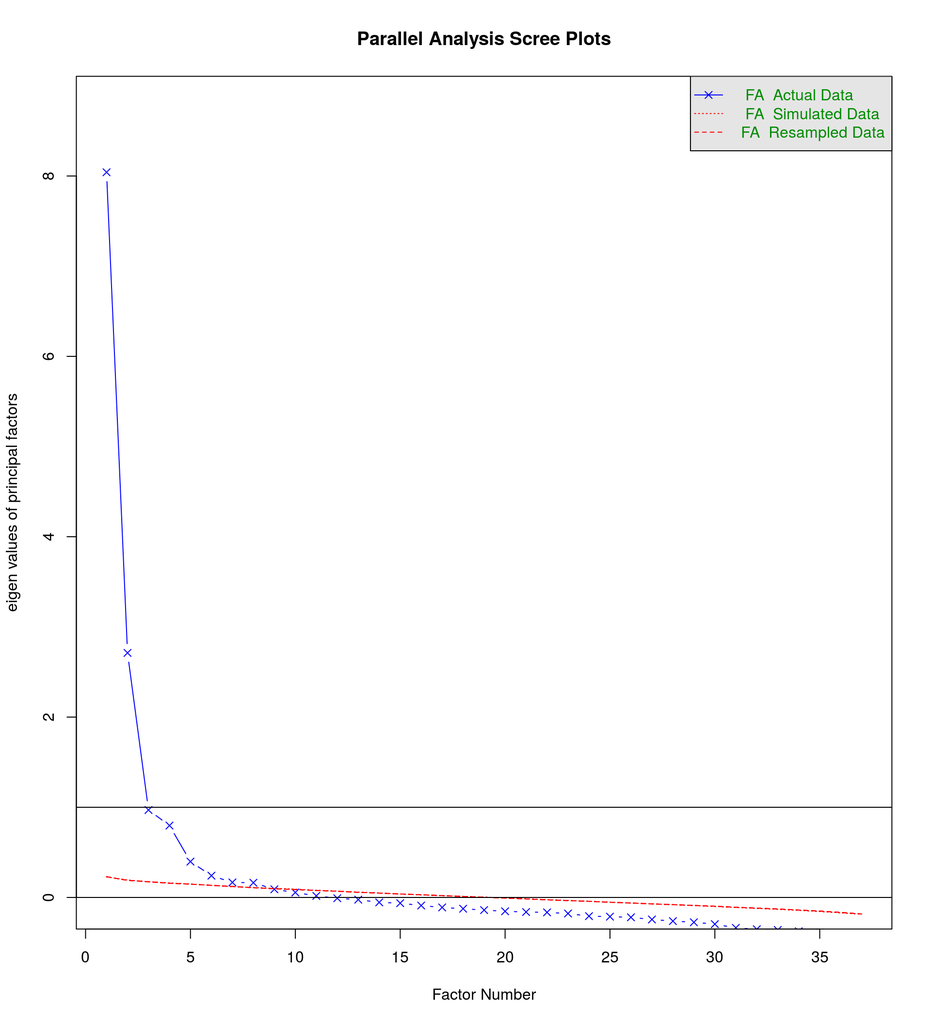

```
## Parallel analysis suggests that the number of factors =  8  and the number of components =  5
```

```r
# Plot Scree Plot
fa.parallel(fullScale, fm="minres", fa="fa", show.legend=TRUE) # yields 4 components
```

### 1.3.4 EFA - Análise fatorial exploratória com dois fatores

```r
faAll <- fa.poly(fullScale, nfactors = 2, rotate = "oblimin")
print.psych(faAll, digits=2, cut=0.3)
```

```
## Factor Analysis using method =  minres
## Call: fa.poly(x = fullScale, nfactors = 2, rotate = "oblimin")
## Standardized loadings (pattern matrix) based upon correlation matrix
##         MR1   MR2   h2   u2 com
## pp001        0.42 0.20 0.80 1.1
## pp002        0.68 0.51 0.49 1.0
## pp003        0.73 0.53 0.47 1.0
## pp004        0.77 0.58 0.42 1.0
## pp005        0.42 0.24 0.76 1.2
## pp006        0.68 0.47 0.53 1.0
## pp007        0.64 0.38 0.62 1.0
## pp008        0.45 0.17 0.83 1.2
## pp009  0.57       0.27 0.73 1.4
## pp010  0.62       0.45 0.55 1.1
## pp011 -0.39       0.14 0.86 1.0
## pp012  0.71       0.49 0.51 1.0
## pp013        0.49 0.37 0.63 1.4
## pp014  0.63       0.35 0.65 1.1
## pp015 -0.47       0.20 0.80 1.0
## pp016  0.61       0.37 0.63 1.0
## pp017        0.64 0.50 0.50 1.1
## pp018        0.40 0.19 0.81 1.1
## pp019  0.53       0.35 0.65 1.1
## pp020  0.58       0.44 0.56 1.2
## pp021  0.70       0.54 0.46 1.0
## pp022  0.56       0.33 0.67 1.0
## pp023        0.51 0.41 0.59 1.4
## pp024        0.67 0.38 0.62 1.2
## pp025        0.40 0.21 0.79 1.1
## pp026  0.63       0.33 0.67 1.2
## pp027  0.70       0.45 0.55 1.0
## pp028        0.57 0.32 0.68 1.0
## pp029  0.64       0.54 0.46 1.2
## pp030  0.61       0.47 0.53 1.1
## pp031  0.75       0.57 0.43 1.0
## pp032  0.64       0.45 0.55 1.0
## pp033  0.30  0.43 0.38 0.62 1.8
## pp034        0.49 0.40 0.60 1.5
## pp035 -0.71       0.52 0.48 1.0
## pp036 -0.69       0.50 0.50 1.0
```

[output cut: 20 more lines]

```
## The root mean square of the residuals (RMSR) is  0.06
## The df corrected root mean square of the residuals is  0.06
##
## The harmonic number of observations is  3064 with the empirical chi square  12413.11  with prob <  0
## The total number of observations was  3064  with MLE Chi Square =  13521.72  with prob <  0
##
## Tucker Lewis Index of factoring reliability =  0.737
## RMSEA index =  0.085  and the 90 % confidence intervals are  NA NA
## BIC =  8761.43
## Fit based upon off diagonal values = 0.97
## Measures of factor score adequacy
##                                                 MR1  MR2
## Correlation of scores with factors             0.97 0.96
## Multiple R square of scores with factors       0.93 0.92
## Minimum correlation of possible factor scores  0.87 0.83
```